# MASZ - Projekt 6 Sieci ewoluujące

Ryszard Szymański

5/3/2020

# Zadania wykładowe

## Zadanie 1

Zaimplementowane funkcję `create_barabasi_albert_graph`:

```r
create_barabasi_albert_graph
```

```
## function (start_nodes_count, edges_per_time_step, time_steps,
##     keep_steps = FALSE)
## {
##     stopifnot(edges_per_time_step <= start_nodes_count)
##     ba_graph <- make_full_graph(n = start_nodes_count, directed = FALSE)
##     graph_steps <- list()
##     for (time_step in seq_len(time_steps)) {
##         vertex_degrees <- degree(ba_graph)
##         vertex_connection_probability <- vertex_degrees/sum(vertex_degrees)
##         vertices_to_connect_with <- sample(seq_along(vertex_degrees),
##             size = edges_per_time_step, prob = vertex_connection_probability)
##         ba_graph <- add_vertices(ba_graph, 1)
##         added_vertex <- vcount(ba_graph)
##         for (vertex_to_connect_with in vertices_to_connect_with) {
##             ba_graph <- ba_graph + edge(added_vertex, vertex_to_connect_with)
##         }
##         if (keep_steps) {
##             graph_steps[[length(graph_steps) + 1]] <- ba_graph
##         }
##     }
##     list(graph = ba_graph, steps = graph_steps)
## }
```

## Zadanie 2

Poniżej przedstawiono animację z tworzenia grafu o 103 wierzchołkach, gdzie w każdej iteracji były dodawane 2 krawedzie.

```r
knitr::include_app("ba_graph_animation.gif")
```

[interactive chart not shown]

## Zadanie 3

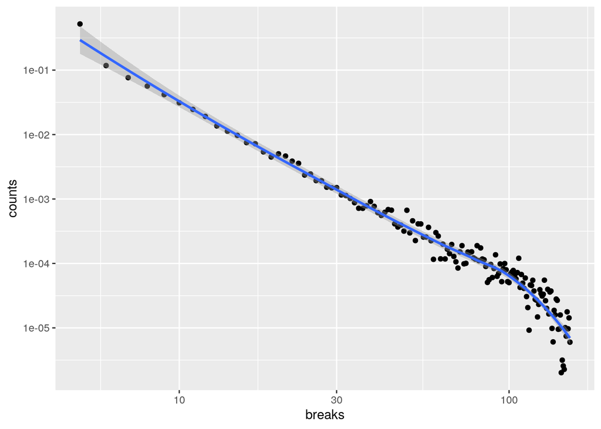

```r
ba_graph_large <- drake::readd(ba_graph_large)

calculate_mean_degrees_hist <- function(graphs) {
  step_degrees_list <- graphs %>%
  lapply(degree)

  breaks <- step_degrees_list %>% unlist() %>% unique() %>% sort()
  mean_degrees_hist <- lapply(step_degrees_list, function(degrees) {
    hist_vals <- hist(degrees, breaks = breaks, plot = F)
    data.frame(breaks = hist_vals$breaks[-1], counts = hist_vals$density)
  }) %>% bind_rows() %>%
    group_by(breaks) %>%
    summarise(counts = mean(counts))
}

mean_degrees_hist <- calculate_mean_degrees_hist(ba_graph_large$steps)

mean_degrees_hist %>%
  ggplot(aes(x = breaks, y = counts)) +
  geom_point() +
  geom_smooth() +
  scale_x_log10() +
  scale_y_log10()
```

Uzyskany rozkład jest rozkładem potęgowym.

## Zadanie 4

Zbadano wartość współczynnika $\alpha$ względem każdego kroku ewolucji tworzonej sieci. Na poniższym wykresie przedstawiono wynik:

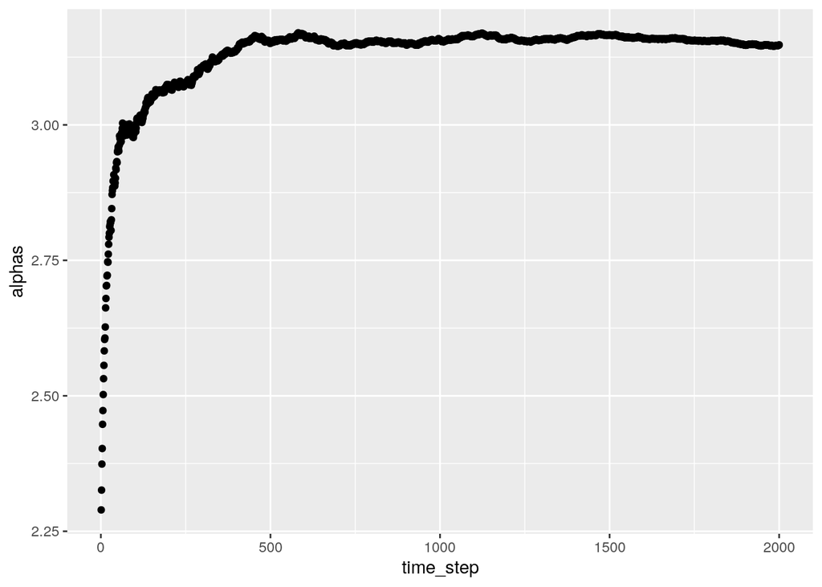

```r
get_single_network_exponent <- function(graph) {
  vertex_degrees <- degree(graph)
  min_degree <- min(vertex_degrees)
  network_exponent(vertex_degrees, min_degree)$alpha
}

alphas <- sapply(ba_graph_large$steps, get_single_network_exponent)
data.frame(time_step = seq_along(ba_graph_large$steps), alphas = alphas) %>%
  ggplot(aes(x = time_step, y = alphas)) +
  geom_point()
```

## Zadanie 5

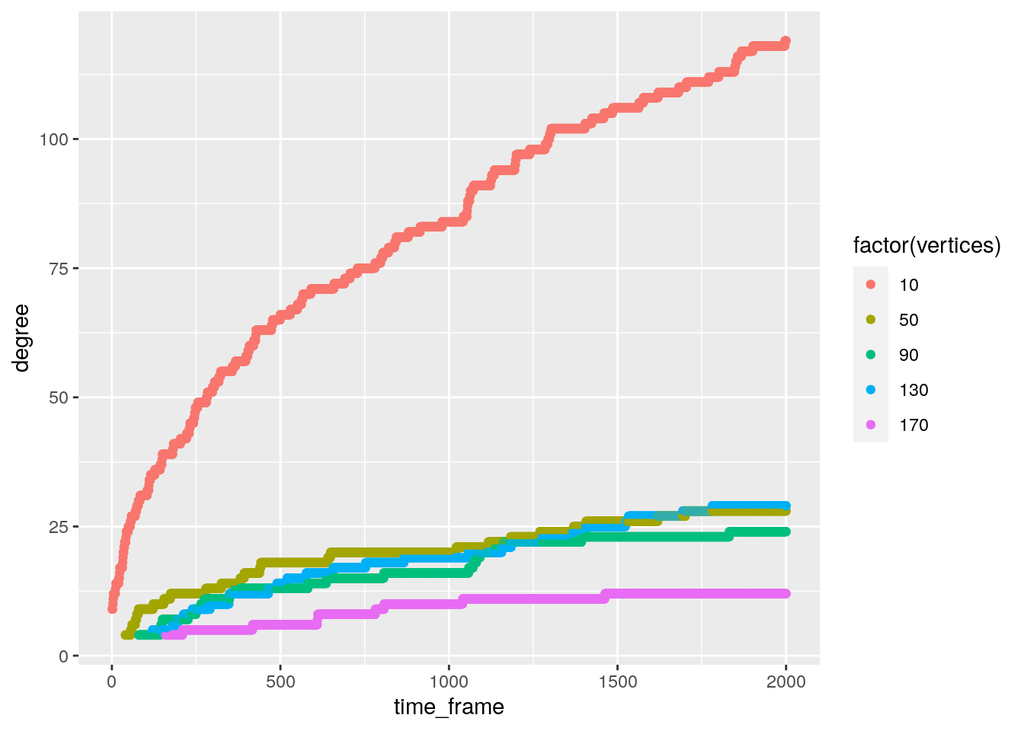

```r
graph_degrees <- lapply(seq_along(ba_graph_large$steps), function(graph_ind) {
  graph <- ba_graph_large$steps[[graph_ind]]
  degrees <- degree(graph)

  data.frame(
    degree = degrees,
    vertices = seq_along(degrees),
    time_frame = graph_ind
  )
}) %>% bind_rows() %>% filter(vertices %in% seq(10, 200, 40))

ggplot(graph_degrees, aes(x = time_frame, y = degree, group = vertices, color = factor(vertices))) +
  geom_point()
```

Uzyskane krzywe są zgodne z teorią:

- Krzywe odpowiadają wykresowi pierwiastka
- Krzywa dla wierzchołkowych dodawanych w późniejszych krokach jest coraz bardziej spłaszczona

## Zadanie 6

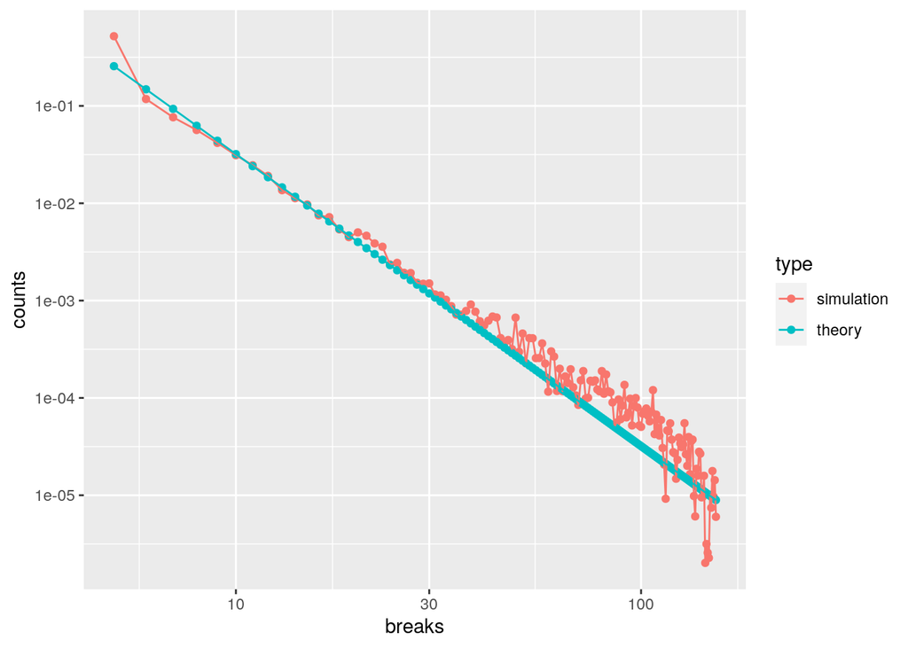

```r
mean_degrees_hist$type = "simulation"
theoretical_results <- data.frame(
  breaks = mean_degrees_hist$breaks,
  counts = (2 * 4^2) / (mean_degrees_hist$breaks)^3,
  type = "theory"
)

bind_rows(mean_degrees_hist, theoretical_results) %>%
  ggplot(aes(x = breaks, y = counts, color = type, group = type)) +
  geom_point() +
  geom_line() +
  scale_x_log10() +
  scale_y_log10()
```

Wartości otrzymane za pomocą uzyskanego wzoru $P(k) = \frac{2m^2}{k^3}$ pokrywają się z empirycznymi wynikami zadania 3.

# Projekt

## Zadanie 9

Przygotowano funkcję `create_barabasi_albert_graph_model_a`, za pomocą której wygenerowano 10 grafów o 1010 wierzchołkach, gdzie w każdej iteracji dodawane było $8$ krawędzi.

```r
create_barabasi_albert_graph_model_a
```

```
## function (start_nodes_count, edges_per_time_step, time_steps)
## {
##     stopifnot(edges_per_time_step <= start_nodes_count)
##     ba_graph <- make_full_graph(n = start_nodes_count, directed = FALSE)
##     graph_steps <- list()
##     for (time_step in seq_len(time_steps)) {
##         vertex_degrees <- degree(ba_graph)
##         vertices_to_connect_with <- sample(seq_along(vertex_degrees),
##             size = edges_per_time_step)
##         ba_graph <- add_vertices(ba_graph, 1)
##         added_vertex <- vcount(ba_graph)
##         for (vertex_to_connect_with in vertices_to_connect_with) {
##             ba_graph <- ba_graph + edge(added_vertex, vertex_to_connect_with)
##         }
##     }
##     ba_graph
## }
```

Uzyskane wyniki pokrywają się rozważaniami teoretycznymi $P(k) = \frac{1}{m} \exp{\left(1 - \frac{k}{m} \right)}$.

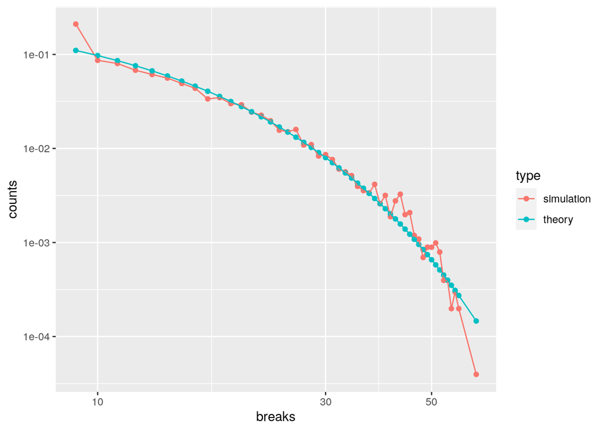

```r
ba_graphs_model_a <- drake::readd(ba_graphs_model_a)
mean_degrees_hist <- calculate_mean_degrees_hist(ba_graphs_model_a)

mean_degrees_hist$type = "simulation"
theoretical_results <- data.frame(
  breaks = mean_degrees_hist$breaks,
  counts = (1/8) * exp(1 - mean_degrees_hist$breaks / 8),
  type = "theory"
)

bind_rows(mean_degrees_hist, theoretical_results) %>%
  ggplot(aes(x = breaks, y = counts, color = type, group = type)) +
  geom_point() +
  geom_line() +
  scale_x_log10() +
  scale_y_log10()
```

## Zadanie 10

Przygotowano funkcję `create_barabasi_albert_graph_model_b`, za pomocą której wygenerowano 3 grafy o 100 wierzchołkach i 1000 krawędzi. Każdy z nich został wygenerowany z różną liczbą iteracji: 50, 500, 10000.

```r
create_barabasi_albert_graph_model_b
```

```
## function (nodes_count, edges_count, time_steps)
## {
##     stopifnot(edges_count <= choose(nodes_count, 2))
##     ba_graph <- random.graph.game(nodes_count, edges_count, type = "gnm")
##     for (time_step in seq_len(time_steps)) {
##         current_edge <- sample(E(ba_graph), size = 1)
##         vertices <- ends(ba_graph, current_edge) %>% as.vector()
##         from_vertex <- vertices[1]
##         vertex_degrees <- degree(ba_graph)
##         vertex_connection_probability <- vertex_degrees/sum(vertex_degrees)
##         vertex_to_connect_with <- sample(seq_along(vertex_degrees)[-from_vertex],
##             size = 1, prob = vertex_connection_probability[-from_vertex])
##         ba_graph <- ba_graph %>% delete_edges(current_edge) %>%
##             add_edges(c(from_vertex, vertex_to_connect_with))
##     }
##     ba_graph
## }
```

Poniżej przedstawiono historamy dla wygenerowanych wykresów:

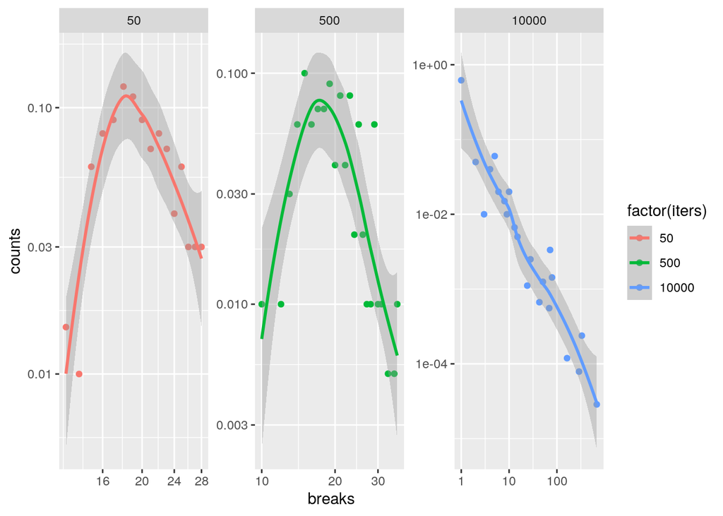

```r
ba_graphs_model_b <- drake::readd(ba_graphs_model_b)
iters <- c(50, 500, 10000)
mean_degrees_hist <- lapply(seq_along(ba_graphs_model_b), function(graph_ind) {
  graph <- ba_graphs_model_b[[graph_ind]]
  iters_count <- iters[graph_ind]
  mean_degrees_hist <- calculate_mean_degrees_hist(list(graph))

  mean_degrees_hist$iters <- iters_count
  mean_degrees_hist
}) %>% bind_rows()

mean_degrees_hist %>%
  ggplot(aes(x = breaks, y = counts, color = factor(iters))) +
  geom_point() +
  geom_smooth() +
  facet_wrap(. ~ iters, scales = "free") +
  scale_x_log10() +
  scale_y_log10()
```

Przy $t \to \infty$ histogram dąży do rozkładu potęgowego, co jest zgodne z opisem modelu B w książce Państwa Frączaków.